# CA_Wildfire_Exploration

William McDonough

AnnaMarie Y. Ho

Amira Cerimi

2024-05-07

# Introduction

By leveraging the comprehensive wildfire occurrence dataset from the U.S. Department of Agriculture, this study seeks to uncover spatial hotspots and temporal trends in California and investigate potential correlations with temperature anomalies. Wildfires present significant economic and environmental challenges, with annual costs in the United States estimated between 394 billion and 893 billion USD [1]. Given time-constraints, we limited our study to California after realizing the acreage burned there was very high compared to other states.

# Data and Transformations

[2] [2.3 Million US Wildfires (1992-2020) 6th Edition](https://www.kaggle.com/datasets/behroozsohrabi/us-wildfire-records-6th-edition)

```
Metadata (only including the data we used):

FIRE_YEAR Calendar year in which the fire was discovered or confirmed to exist.

DISCOVERY_DATE Date on which the fire was discovered or confirmed to exist.

DISCOVERY_DOY Day of year on which the fire was discovered or confirmed to exist.

DISCOVERY_TIME Time of day that the fire was discovered or confirmed to exist.

CONT_DATE Date on which the fire was declared contained or otherwise controlled (mm/dd/yyyy where mm=month, dd=day, and yyyy=year).

CONT_DOY Day of year on which the fire was declared contained or otherwise controlled.

CONT_TIME Time of day that the fire was declared contained or otherwise controlled (hhmm where hh=hour, mm=minutes).

FIRE_SIZE The estimate of acres within the final perimeter of the fire.

FIRE_SIZE_CLASS Code for fire size based on the number of acres within the final fire perimeter (A=greater than 0 but less than or equal to 0.25 acres, B=0.26-9.9 acres, C=10.0-99.9 acres, D=100-299 acres, E=300 to 999 acres, F=1000 to 4999 acres, and G=5000+ acres).

LATITUDE Latitude (NAD83) for point location of the fire (decimal degrees).

LONGITUDE Longitude (NAD83) for point location of the fire (decimal degrees).

STATE Two-letter alphabetic code for the state in which the fire burned (or originated), based on the nominal designation in the fire report (not from a spatial overlay).

COUNTY County, or equivalent, in which the fire burned (or originated), based on nominal designation in the fire report (not from a spatial overlay).
```

[3] [Climate at a Glance](https://www.ncei.noaa.gov/access/monitoring/climate-at-a-glance/statewide/time-series)

```
Metadata:
Date year and month formatted YYYYMM

Value average temperature in degrees farenheit

Anomaly difference in average and baseline (1901-2000 base period)
```

## Libraries

```r
# R packages
list.of.packages <- c('ggplot2',
                      'dplyr',
                      'ggiraphExtra',
                      'sf',
                      'maps',
                      'mapproj',
                      'tigris',
                      'plotly',
                      'scales',
                      'zoo',
                      'corrplot',
                      'knitr',
                      'kableExtra',
                      'htmltools')

new.packages <- list.of.packages[!(list.of.packages %in%
                                     installed.packages()[,"Package"])]

if(length(new.packages)) {
  install.packages(new.packages, repo='http://cran.at.r-project.org',
                   dependencies=TRUE)
}

# Load all packages
lapply(list.of.packages, library, character.only = TRUE)
```

## Data Transformations

### Wildfire Data

After downloading the wildfire database, we need to read it into R and take the `Fires` table

```r
# Install RSQLite if not already installed
if (!requireNamespace("RSQLite", quietly = TRUE)) {
  install.packages("RSQLite")
}

# Load the RSQLite package
library(RSQLite)

# Establish a connection to the SQLite database
db <- dbConnect(RSQLite::SQLite(), dbname = "../raw_data/fires_db.sqlite")

# Query the database, might take a second
query_result <- dbGetQuery(db, "SELECT * FROM Fires")

# The query_result is now a dataframe with the contents of 'Fires'
head(query_result)  # Verify this output with query_result.txt in Scripts
```

```
##   OBJECTID      Shape FOD_ID     FPA_ID SOURCE_SYSTEM_TYPE SOURCE_SYSTEM
## 1        1 blob[60 B]      1 FS-1418826                FED   FS-FIRESTAT
## 2        2 blob[60 B]      2 FS-1418827                FED   FS-FIRESTAT
## 3        3 blob[60 B]      3 FS-1418835                FED   FS-FIRESTAT
## 4        4 blob[60 B]      4 FS-1418845                FED   FS-FIRESTAT
## 5        5 blob[60 B]      5 FS-1418847                FED   FS-FIRESTAT
## 6        6 blob[60 B]      6 FS-1418849                FED   FS-FIRESTAT
##   NWCG_REPORTING_AGENCY NWCG_REPORTING_UNIT_ID NWCG_REPORTING_UNIT_NAME
## 1                    FS                USCAPNF   Plumas National Forest
## 2                    FS                USCAENF Eldorado National Forest
## 3                    FS                USCAENF Eldorado National Forest
## 4                    FS                USCAENF Eldorado National Forest
## 5                    FS                USCAENF Eldorado National Forest
## 6                    FS                USCAENF Eldorado National Forest
##   SOURCE_REPORTING_UNIT SOURCE_REPORTING_UNIT_NAME LOCAL_FIRE_REPORT_ID
```

[output cut: 48 more lines]

```r
# Save the dataframe to disk as an R data file
saveRDS(query_result, file = "Data/fires_df.rds")

# Disconnect from the database
dbDisconnect(db)

# Get the columns of interest and rename them
fires <- query_result %>%
  select(FIRE_YEAR,
         STATE,
         COUNTY,
         DISCOVERY_DOY,
         CONT_DOY,
         FIRE_SIZE_CLASS,
         FIRE_SIZE,
         NWCG_CAUSE_CLASSIFICATION) %>%
  rename(year = FIRE_YEAR,
         state = STATE,
         county = COUNTY,
         day_discovered = DISCOVERY_DOY,
         day_contained = CONT_DOY,
         class = FIRE_SIZE_CLASS,
         size = FIRE_SIZE,
         cause = NWCG_CAUSE_CLASSIFICATION)

head(fires)
```

```
##   year state county day_discovered day_contained class size   cause
## 1 2005    CA     63             33            33     A 0.10   Human
## 2 2004    CA     61            133           133     A 0.25 Natural
## 3 2004    CA     17            152           152     A 0.10   Human
## 4 2004    CA      3            180           185     A 0.10 Natural
## 5 2004    CA      3            180           185     A 0.10 Natural
## 6 2004    CA      5            182           183     A 0.10 Natural
```

### Temperature Data

After downloading the CA temperatures csv we want to load it into a df, calculate moving averages, and reformat dates for plotting. We are generating a df for both monthly and annual temperatures

```r
# Load California temps (Base Period: 1901-2000)
ca_temps_df <- as.data.frame(read.csv("Data/ca_temps_monthly_raw.csv"))
head(ca_temps_df)
```

```
##     Date Value Anomaly
## 1 199201  43.2     0.9
## 2 199202  49.1     3.8
## 3 199203  50.8     2.0
## 4 199204  58.9     4.9
## 5 199205  67.0     6.3
## 6 199206  69.0     0.7
```

```r
# Calculate moving averages
ca_temps_df$anomaly_mv_avg <- rollmean(ca_temps_df$Anomaly,
                                   5,
                                   fill = NA,
                                   align = "center")

ca_temps_df$temp_mv_avg <- rollmean(ca_temps_df$Value,
                                       5,
                                       fill = NA,
                                       align = "center")

# Convert these to the first day of the given month for accurate representation
ca_temps_df$Date <- as.Date(paste0(substr(ca_temps_df$Date, 1, 4), "-",
                                   substr(ca_temps_df$Date, 5, 6), "-01"))
# Get month
ca_temps_df$month <- format(ca_temps_df$Date, "%m")

# Get year
ca_temps_df$year <- format(ca_temps_df$Date, "%Y")

# for some reason they are <chr>
ca_temps_df$year <- as.integer(ca_temps_df$year)
ca_temps_df$month <- as.integer(ca_temps_df$month)
str(ca_temps_df)
```

```
## 'data.frame':    348 obs. of  7 variables:
##  $ Date          : Date, format: "1992-01-01" "1992-02-01" ...
##  $ Value         : num  43.2 49.1 50.8 58.9 67 69 73.8 76.2 70.8 62.6 ...
##  $ Anomaly       : num  0.9 3.8 2 4.9 6.3 0.7 -0.9 2.5 2.3 3.1 ...
##  $ anomaly_mv_avg: num  NA NA 3.58 3.54 2.6 2.7 2.18 1.54 1.4 1.02 ...
##  $ temp_mv_avg   : num  NA NA 53.8 59 63.9 ...
##  $ month         : int  1 2 3 4 5 6 7 8 9 10 ...
##  $ year          : int  1992 1992 1992 1992 1992 1992 1992 1992 1992 1992 ...
```

```r
# GGplot needs custom labels or it just jumbles everything on the x axis
ca_temps_df$label <- ifelse(ca_temps_df$month == 01, as.character(ca_temps_df$year), "")

head(ca_temps_df, 13) # so you can see 2 labels
```

```
##          Date Value Anomaly anomaly_mv_avg temp_mv_avg month year label
## 1  1992-01-01  43.2     0.9             NA          NA     1 1992  1992
## 2  1992-02-01  49.1     3.8             NA          NA     2 1992
## 3  1992-03-01  50.8     2.0           3.58       53.80     3 1992
## 4  1992-04-01  58.9     4.9           3.54       58.96     4 1992
## 5  1992-05-01  67.0     6.3           2.60       63.90     5 1992
## 6  1992-06-01  69.0     0.7           2.70       68.98     6 1992
## 7  1992-07-01  73.8    -0.9           2.18       71.36     7 1992
## 8  1992-08-01  76.2     2.5           1.54       70.48     8 1992
## 9  1992-09-01  70.8     2.3           1.40       66.58     9 1992
## 10 1992-10-01  62.6     3.1           1.02       59.88    10 1992
## 11 1992-11-01  49.5     0.0           0.32       52.90    11 1992
## 12 1992-12-01  40.3    -2.8          -0.40       47.54    12 1992
## 13 1993-01-01  41.3    -1.0          -0.20       45.60     1 1993  1993
```

```r
# need a df for monthly and annual
ca_monthly_temps <- ca_temps_df %>%
  mutate(
    year_month = factor(paste(year, month, sep = "-"), levels = paste(year, month, sep = "-"))) %>%
  select(
    year,
    month,
    year_month,
    Value,
    Anomaly,
    temp_mv_avg,
    label) %>%
  rename(
    value = Value,
    anomaly = Anomaly) %>%
  arrange(year, month)

ca_annual_temps <- ca_monthly_temps %>%
  select(year, value, label) %>%
  group_by(year) %>%
  summarise(annual_mean = mean(value, na.rm = TRUE),
            label = first(label),
            .groups = 'drop')

# Calculate moving average (didn't work in summarise())
ca_annual_temps <- ca_annual_temps %>%
  mutate(moving_avg = rollmean(annual_mean, k = 5, fill = NA, align = 'center'))

str(ca_annual_temps)
```

```
## tibble [29 × 4] (S3: tbl_df/tbl/data.frame)
##  $ year       : int [1:29] 1992 1993 1994 1995 1996 1997 1998 1999 2000 2001 ...
##  $ annual_mean: num [1:29] 59.3 57.7 58 58.9 59.6 ...
##  $ label      : chr [1:29] "1992" "1993" "1994" "1995" ...
##  $ moving_avg : num [1:29] NA NA 58.7 58.7 58.5 ...
```

```r
head(ca_annual_temps)
```

```
## # A tibble: 6 × 4
##    year annual_mean label moving_avg
##   <int>       <dbl> <chr>      <dbl>
## 1  1992        59.3 1992        NA
## 2  1993        57.7 1993        NA
## 3  1994        58.0 1994        58.7
## 4  1995        58.9 1995        58.7
## 5  1996        59.6 1996        58.5
## 6  1997        59.1 1997        58.5
```

### Combined Data

Here we make simply combine the two datasets into a usable df and calculate some moving averages for plotting:

```r
ca_fires <- fires %>%
  filter(state == "CA") %>%
  group_by(year) %>%
  summarise(number_of_fires = n()/100, # scaling for visual clarity
            natural_tot = sum(cause == "Natural")/100, # divide by 100 to
            human_tot = sum(cause == "Human")/100,    # match number_of_fires
            mean_acreage_burned = mean(size),
            pct_human = human_tot/number_of_fires*100)

head(ca_fires)
```

```
## # A tibble: 6 × 6
##    year number_of_fires natural_tot human_tot mean_acreage_burned pct_human
##   <int>           <dbl>       <dbl>     <dbl>               <dbl>     <dbl>
## 1  1992           108.        27.0       81.2                27.4      75.0
## 2  1993            82.7        7.04      75.4                38.9      91.2
## 3  1994            86.5       15.0       71.3                47.1      82.4
## 4  1995            73.8        5.49      68.2                29.3      92.4
## 5  1996            91.7       14.1       77.4                77.1      84.4
## 6  1997            79.3       11.0       68.2                40.9      86.0
```

```r
# join and get moving average
ca_combined_data <- left_join(ca_annual_temps, ca_fires, by = "year")
ca_combined_data <- ca_combined_data %>%
  mutate(fires_moving_avg = rollmean(number_of_fires, k = 5, fill = NA, align = 'center'),
         acres_moving_avg = rollmean(mean_acreage_burned, k = 5, fill = NA, align = 'center'),
         human_moving_avg = rollmean(human_tot, k = 5, fill = NA, align = 'center'),
         natural_moving_avg = rollmean(natural_tot, k = 5, fill = NA, align = 'center'),
         temp_moving_avg = rollmean(annual_mean, k = 5, fill = NA, align = 'center')) %>%
  rename(temp_annual_mean = annual_mean)

head(ca_combined_data)
```

```
## # A tibble: 6 × 14
##    year temp_annual_mean label moving_avg number_of_fires natural_tot human_tot
##   <int>            <dbl> <chr>      <dbl>           <dbl>       <dbl>     <dbl>
## 1  1992             59.3 1992        NA             108.        27.0       81.2
## 2  1993             57.7 1993        NA              82.7        7.04      75.4
## 3  1994             58.0 1994        58.7            86.5       15.0       71.3
## 4  1995             58.9 1995        58.7            73.8        5.49      68.2
## 5  1996             59.6 1996        58.5            91.7       14.1       77.4
## 6  1997             59.1 1997        58.5            79.3       11.0       68.2
## # ℹ 7 more variables: mean_acreage_burned <dbl>, pct_human <dbl>,
## #   fires_moving_avg <dbl>, acres_moving_avg <dbl>, human_moving_avg <dbl>,
## #   natural_moving_avg <dbl>, temp_moving_avg <dbl>
```

This was used to get states, because `stateR` was not working.

```r
state_abbreviations <- c(
  "Alabama" = "AL", "Alaska" = "AK", "Arizona" = "AZ", "Arkansas" = "AR", "California" = "CA",
  "Colorado" = "CO", "Connecticut" = "CT", "Delaware" = "DE", "Florida" = "FL", "Georgia" = "GA",
  "Hawaii" = "HI", "Idaho" = "ID", "Illinois" = "IL", "Indiana" = "IN", "Iowa" = "IA",
  "Kansas" = "KS", "Kentucky" = "KY", "Louisiana" = "LA", "Maine" = "ME", "Maryland" = "MD",
  "Massachusetts" = "MA", "Michigan" = "MI", "Minnesota" = "MN", "Mississippi" = "MS", "Missouri" = "MO",
  "Montana" = "MT", "Nebraska" = "NE", "Nevada" = "NV", "New Hampshire" = "NH", "New Jersey" = "NJ",
  "New Mexico" = "NM", "New York" = "NY", "North Carolina" = "NC", "North Dakota" = "ND",
  "Ohio" = "OH", "Oklahoma" = "OK", "Oregon" = "OR", "Pennsylvania" = "PA", "Rhode Island" = "RI",
  "South Carolina" = "SC", "South Dakota" = "SD", "Tennessee" = "TN", "Texas" = "TX",
  "Utah" = "UT", "Vermont" = "VT", "Virginia" = "VA", "Washington" = "WA", "West Virginia" = "WV",
  "Wisconsin" = "WI", "Wyoming" = "WY")
```

# Results

### Heatmap, Acreage Burned by State

Plotting the acreage burned by state illustrates why we chose CA for our first exploration. Note that AK and HI are removed as their scale throws off the map and eliminates any discernable differences in the continental states:

```r
# first get the acreage burned by state
state_total_acreage <- fires %>%
  mutate(state <- tolower(state)) %>%
  group_by(state) %>%
  summarise(tot_acreage = sum(size))

# generate a map
options(tigris_class = "sf")  # Ensure it returns sf objects
# cb = TRUE gives us a low-res version for quicker plotting
states_sf <- tigris::states(cb = TRUE)
states_sf <- states_sf %>%
  mutate(NAME = state_abbreviations[NAME])
states_sf <- states_sf %>%
  filter(!is.na(NAME))
# ensure you have the same identifiers
state_total_acreage$state <- trimws(state_total_acreage$state)
print(unique(states_sf$NAME))
print(unique(state_total_acreage$state))

# Merge using the common 'state' abbreviation column
choropleth_data <- merge(states_sf,
                         state_total_acreage,
                         by.x = "NAME",
                         by.y = "state",
                         all.x = TRUE)

choropleth_data <- choropleth_data %>%
  filter(!NAME %in% c("AK", "HI"))  # Exclude both Alaska and Hawaii due to scale
```

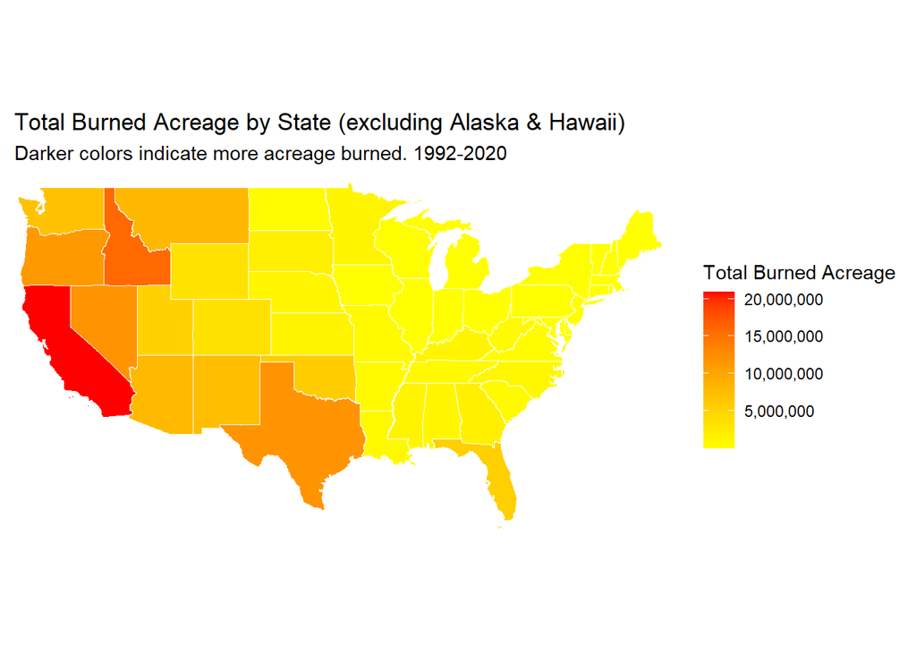

```r
ggplot_map <- ggplot(data = choropleth_data) +
  geom_sf(aes(fill = tot_acreage),
          color = "white",
          size = 0.1) +
  scale_fill_gradient(low = "yellow",
                      high = "red",
                      name = "Total Burned Acreage",
                      labels = scales::comma) +  # Adjust scale labels to standard numbering
  labs(title = "Total Burned Acreage by State (excluding Alaska & Hawaii)",
       subtitle = "Darker colors indicate more acreage burned. 1992-2020",
       x = NULL, # Remove axis titles
       y = NULL) +  # They are just coordinate labels
  theme_minimal() +
  theme(axis.text.x = element_blank(),  # Remove X axis text
        axis.text.y = element_blank(),  # Remove Y axis text
        axis.ticks = element_blank(),   # Remove axis ticks
        panel.grid.major = element_blank(),  # Remove major grid lines
        panel.grid.minor = element_blank(),  # Remove minor grid lines
        plot.background = element_blank()) +
  coord_sf(xlim = c(-125, -66),
           ylim = c(24, 50),
           expand = FALSE)

ggplot_map
```

### Linegraph, CA Temperature Anomalies

When looking at the anomalies, we see an observed increase in temperature anomaly from around 2011.

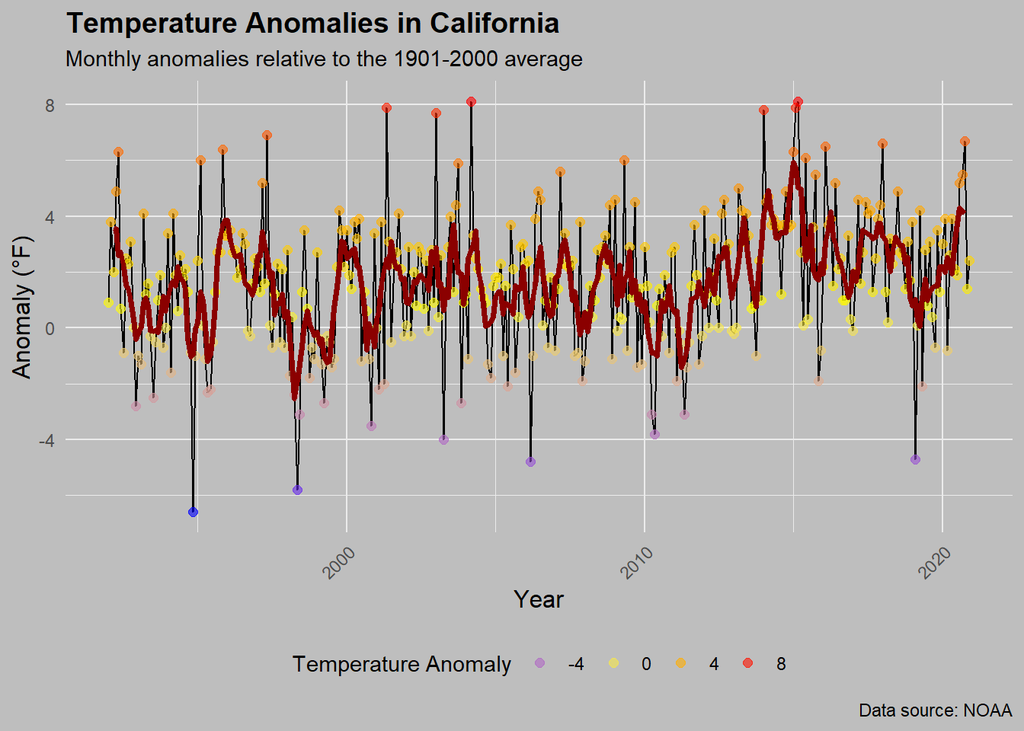

```r
ca_anomalies_lineplot<- ggplot(ca_temps_df, aes(x = Date, y = Anomaly)) +
  geom_line(color = "black") +  # Adding a custom color to the line
  geom_point(aes(color = Anomaly), size = 2, alpha = 0.6) +  # Adding points
  geom_line(aes(y = anomaly_mv_avg), color = "darkred", size = 1.25) + # Anomaly moving Average
  scale_color_gradientn(colors = c("blue", "yellow", "red")) +  # Color gradient for points
  labs(
    title = "Temperature Anomalies in California",
    subtitle = "Monthly anomalies relative to the 1901-2000 average",
    x = "Year",
    y = "Anomaly (°F)",
    caption = "Data source: NOAA"
  ) +
  theme_minimal() +  # Minimalist theme
  theme(
    plot.background = element_rect(fill = "grey", color = "grey"),  # Set background to grey
    panel.background = element_rect(fill = "grey", color = "grey"),  # Match panel background
    text = element_text(color = "black"),  # Change text color to black for visibility
    axis.text.x = element_text(angle = 45, hjust = 1),
    legend.position = "bottom",
    plot.title = element_text(face = "bold", size = 14),
    axis.title = element_text(size = 12)
  ) +
  guides(color = guide_legend(title = "Temperature Anomaly"))

ca_anomalies_lineplot
```

### Barplots, California Temperatures

Here we plot monthly and annual temperatures to see any apparent trends:

Monthly doesn’t offer much insight:

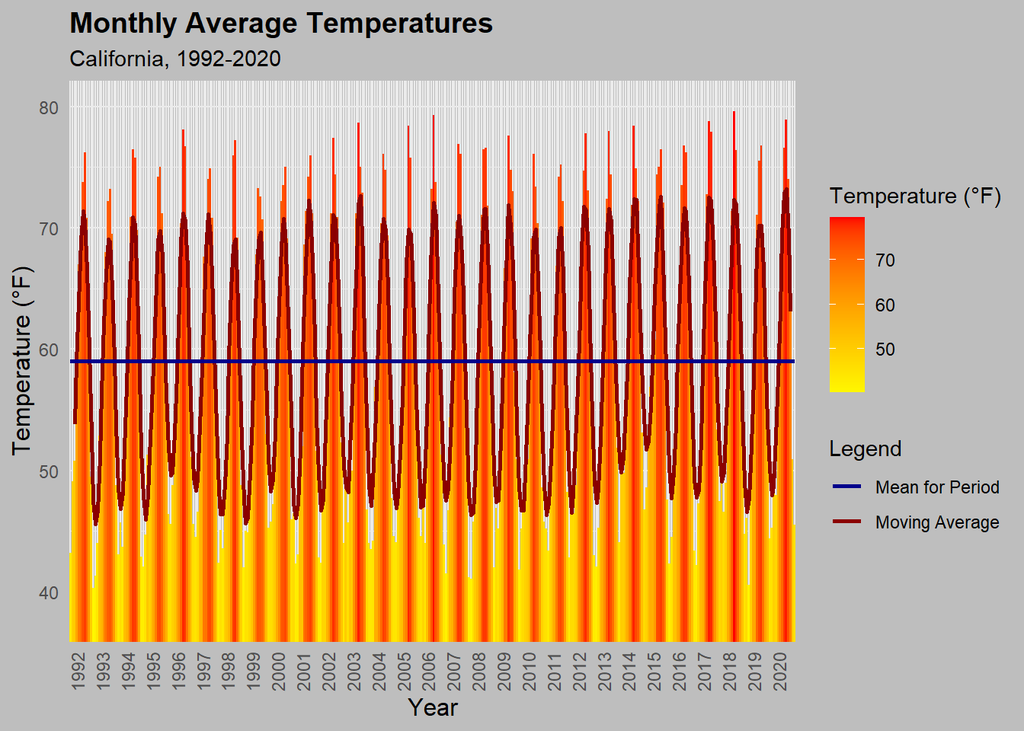

```r
# for plot
overall_value_mean <- mean(ca_monthly_temps$value, na.rm = TRUE)

monthly_barplot <- ggplot(ca_monthly_temps, aes(x = year_month, y = value, fill = value)) +
  geom_col(width = 1) +  # width = 1 for no gaps
  geom_line(aes(y = temp_mv_avg, group = 1, color = "Moving Average"), size = 1) +
  geom_line(aes(y = overall_value_mean, group = 1, color = "Mean for Period"), size = 1) +
  labs(title = "Monthly Average Temperatures",
       subtitle = "California, 1992-2020",
       x = "Year",
       y = "Temperature (°F)",
       color = "Legend") +
  theme_minimal() +
  theme(plot.background = element_rect(fill = "grey", color = "grey"),  # Set background to grey
        panel.background = element_rect(fill = "grey", color = "grey"),  # Match panel background
        text = element_text(color = "black"),  # Change text color to black for visibility
        axis.text.x = element_text(angle = 90, hjust = 1),
        legend.position = "right",
        plot.title = element_text(face = "bold", size = 14),
        axis.title = element_text(size = 12)) + # Rotate x-axis labels for clarity
  scale_x_discrete(labels = ca_monthly_temps$label) +
  coord_cartesian(ylim = c(38, 80)) +
  scale_fill_gradient2(low = "yellow",
                       mid = "orange",
                       high = "red",
                       midpoint = overall_value_mean,
                       limits = c(min(ca_monthly_temps$value, na.rm = TRUE),
                                  max(ca_monthly_temps$value, na.rm = TRUE)),
                       name = "Temperature (°F)") +
  scale_color_manual(values = c("Moving Average" = "darkred",
                                "Mean for Period" = "darkblue"))

print(monthly_barplot)
```

However, annually we see some interesting trends:

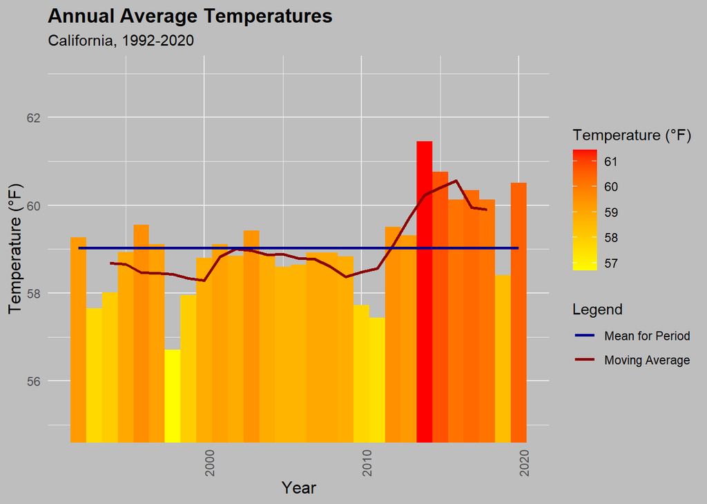

```r
annual_barplot <- ggplot(ca_annual_temps, aes(x = year, y = annual_mean, fill = annual_mean)) +
  geom_col(width = 1) +
  geom_line(aes(y = moving_avg, group = 1, color = "Moving Average"), size = 1) +
  geom_line(aes(y = overall_value_mean, group = 1, color = "Mean for Period"), size = 1) +
  labs(title = "Annual Average Temperatures",
       subtitle = "California, 1992-2020",
       x = "Year",
       y = "Temperature (°F)",
       color = "Legend") +
  theme_minimal() +
  theme(plot.background = element_rect(fill = "grey", color = "grey"),  # Set background to grey
        panel.background = element_rect(fill = "grey", color = "grey"),  # Match panel background
        text = element_text(color = "black"),  # Change text color to black for visibility
        axis.text.x = element_text(angle = 90, hjust = 1),
        legend.position = "right",
        plot.title = element_text(face = "bold", size = 14),
        axis.title = element_text(size = 12)) +
  coord_cartesian(ylim = c(55, 63)) +
  scale_fill_gradient2(low = "yellow",
                       mid = "orange",
                       high = "red",
                       midpoint = overall_value_mean,
                       limits = c(min(ca_annual_temps$annual_mean, na.rm = TRUE),
                                  max(ca_annual_temps$annual_mean, na.rm = TRUE)),
                       name = "Temperature (°F)") +
  scale_color_manual(values = c("Moving Average" = "darkred",
                                "Mean for Period" = "darkblue"))

print(annual_barplot)
```

It appears the temperature has been increasing from 2011 onward, coinciding with the observed increase in temperature anomaly. The question is now whether this trend correlates to an increase in annual fires reported or annual acreage burned.

### Bar and Line Plot, California Wildfires and Temperatures

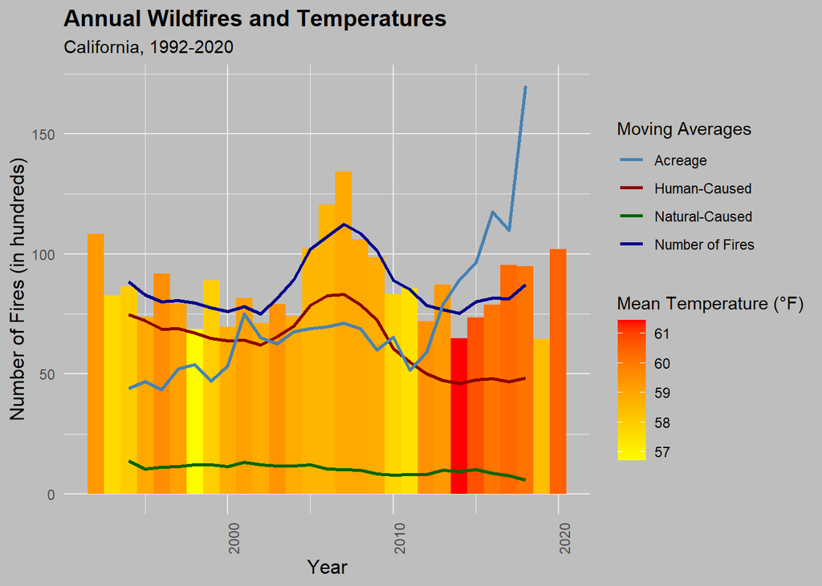

```r
combined_barplot <- ggplot(ca_combined_data, aes(x = year, y = number_of_fires, fill = temp_annual_mean)) +
  geom_col(width = 1) +
  geom_line(aes(y = human_moving_avg, group = 1, color = "Human-Caused"), size = 1) +
  geom_line(aes(y = natural_moving_avg, group = 1, color = "Natural-Caused"), size = 1) +
  geom_line(aes(y = fires_moving_avg, group = 1, color = "Number of Fires"), size = 1) +
  geom_line(aes(y = acres_moving_avg, group = 1, color = "Acreage"), size = 1) +
  labs(title = "Annual Wildfires and Temperatures",
       subtitle = "California, 1992-2020",
       x = "Year",
       y = "Number of Fires (in hundreds)",
       color = "Moving Averages") +
  theme_minimal() +
  theme(plot.background = element_rect(fill = "grey", color = "grey"),
        panel.background = element_rect(fill = "grey", color = "grey"),
        text = element_text(color = "black"),
        axis.text.x = element_text(angle = 90, hjust = 1),
        legend.position = "right",
        plot.title = element_text(face = "bold", size = 14),
        axis.title = element_text(size = 12)) +
  # coord_cartesian(ylim = c(45, 175)) +
  scale_fill_gradient2(low = "yellow",
                       mid = "orange",
                       high = "red",
                       midpoint = mean(ca_combined_data$temp_annual_mean, na.rm = TRUE),
                       limits = c(min(ca_combined_data$temp_annual_mean, na.rm = TRUE),
                                  max(ca_combined_data$temp_annual_mean, na.rm = TRUE)),
                       name = "Mean Temperature (°F)") +
  scale_color_manual(values = c("Number of Fires" = "darkblue",
                                "Acreage" = "steelblue",
                                "Human-Caused" = "darkred",
                                "Natural-Caused" = "darkgreen")
                     )

print(combined_barplot)
```

Here we see an obvious sharp increase in the amount of acreage burned following 2010. Also note the overall decrease and apparent leveling of the percentage of human- caused fires.

We have observed an apparent increase in temperature coinciding with a sharp increase in acres burned. Now we move on to statistical testing. How are these variables related and is that relationship statistically meaningful?

### Statistics

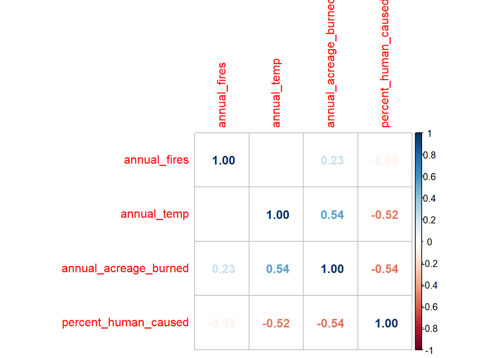

```r
# Correlation Testing

fires_pre_cor <- ca_combined_data %>%
  select(number_of_fires,
         temp_annual_mean,
         mean_acreage_burned,
         pct_human) %>%
  rename(annual_fires = number_of_fires,
         annual_temp = temp_annual_mean,
         annual_acreage_burned = mean_acreage_burned,
         percent_human_caused = pct_human)

fires_cor <- cor(fires_pre_cor)
corrplot(fires_cor, method = "number")
```

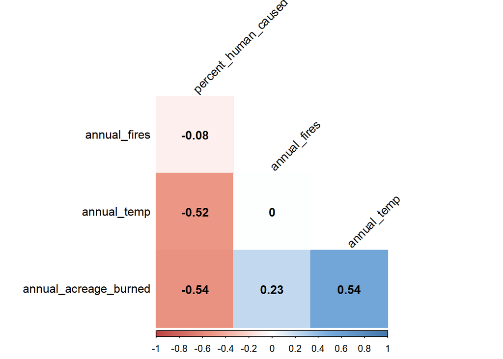

```r
col <- colorRampPalette(c("#BB4444",
                          "#EE9988",
                          "#FFFFFF",
                          "#77AADD",
                          "#4477AA"))

corrplot(fires_cor,
         method="color",
         col=col(200),
         type="lower",
         order="hclust",
         addCoef.col="black",
         tl.col="black",
         tl.srt=45,
         diag=F)
```

```r
cor_test_result <- cor.test(fires_pre_cor$annual_temp, fires_pre_cor$annual_acreage_burned)

cor_test_df <- data.frame(
  Estimate = cor_test_result$estimate,
  Statistic = cor_test_result$statistic,
  DF = cor_test_result$parameter,
  P.value = cor_test_result$p.value,
  Confidence.Interval = paste(round(cor_test_result$conf.int[1], 3), "to", round(cor_test_result$conf.int[2], 3))
)

# Use kable() for table
table_output <- kable(cor_test_df, format = "html", caption = "Temp & Acreage Correlation") %>%
  kable_styling(full_width = FALSE, position = "left", bootstrap_options = c("striped", "hover", "condensed", "bordered")) %>%
  column_spec(1, bold = TRUE, border_right = TRUE) %>%
  row_spec(0, bold = TRUE, color = "black", background = "lightgrey")

table_output
```

Temp & Acreage Correlation

|  | Estimate | Statistic | DF | P.value | Confidence.Interval |
| --- | --- | --- | --- | --- | --- |
| cor | 0.5416071 | 3.347808 | 27 | 0.0024102 | 0.218 to 0.758 |

Notes: annual fires is not meaningfully correlated to how many are human-caused. annual temperature has a negative correlation with percent human-caused. annual acreage burned has a negative correlation with percent human-caused and positive correlations with mean annual fires and mean annual temperature.

Next we will explore how significant the acreage correlations are:

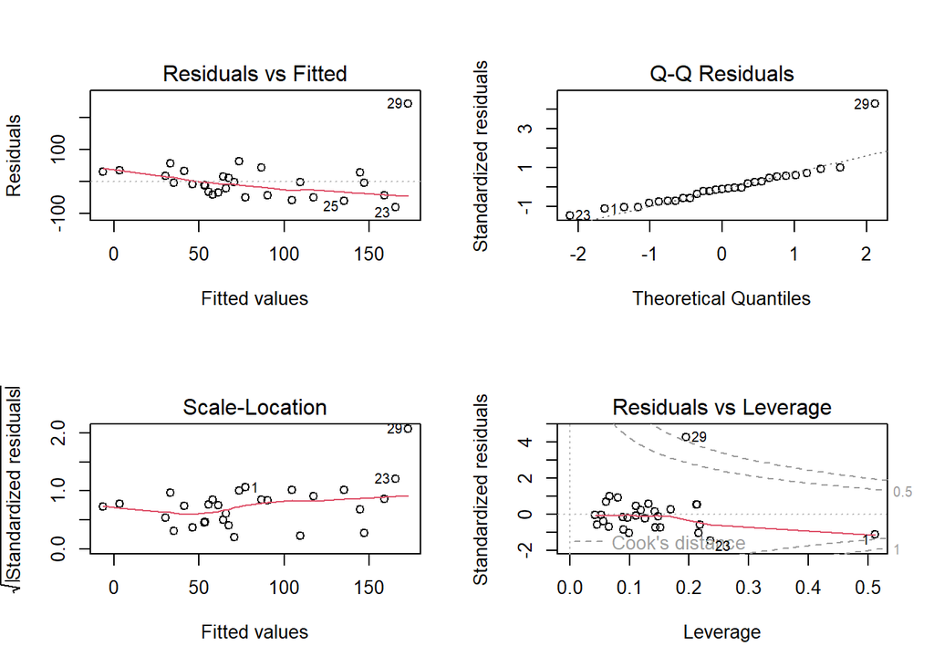

```r
# Linear Regression acreage v year, temp, and pct human

model <- lm(mean_acreage_burned ~ year +
              temp_annual_mean +
              pct_human,
            data = ca_combined_data)
par(mfrow = c(2, 2))
plot(model)
```

```r
summary(model)
```

```
##
## Call:
## lm(formula = mean_acreage_burned ~ year + temp_annual_mean +
##     pct_human, data = ca_combined_data)
##
## Residuals:
##     Min      1Q  Median      3Q     Max
## -81.397 -42.471  -5.778  27.499 244.099
##
## Coefficients:
##                    Estimate Std. Error t value Pr(>|t|)
## (Intercept)      -1988.5707  6941.0601  -0.286   0.7769
## year                 0.3337     3.4009   0.098   0.9226
## temp_annual_mean    26.1447    13.4810   1.939   0.0638 .
## pct_human           -1.9804     2.3429  -0.845   0.4060
## ---
## Signif. codes:  0 '***' 0.001 '**' 0.01 '*' 0.05 '.' 0.1 ' ' 1
##
## Residual standard error: 63.57 on 25 degrees of freedom
## Multiple R-squared:  0.3857, Adjusted R-squared:  0.312
## F-statistic: 5.233 on 3 and 25 DF,  p-value: 0.006095
```

```r
# point 29 seems to be influencing the regression model a lot
point_29 <- ca_combined_data[29, ]
print(point_29)
```

```
## # A tibble: 1 × 14
##    year temp_annual_mean label moving_avg number_of_fires natural_tot human_tot
##   <int>            <dbl> <chr>      <dbl>           <dbl>       <dbl>     <dbl>
## 1  2020             60.5 2020          NA            102.        6.39      48.8
## # ℹ 7 more variables: mean_acreage_burned <dbl>, pct_human <dbl>,
## #   fires_moving_avg <dbl>, acres_moving_avg <dbl>, human_moving_avg <dbl>,
## #   natural_moving_avg <dbl>, temp_moving_avg <dbl>
```

```r
# Calculate leverage
influence_measures <- influence.measures(model)
print(influence_measures)
```

```
## Influence measures of
##   lm(formula = mean_acreage_burned ~ year + temp_annual_mean +      pct_human, data = ca_combined_data) :
##
##       dfb.1_  dfb.year dfb.tm__  dfb.pct_   dffit   cov.r   cook.d    hat inf
## 1  -1.087622  1.109084 -0.22417  0.923767 -1.1554 1.96118 3.30e-01 0.5118   *
## 2   0.053846 -0.046472 -0.07230  0.012997  0.2313 1.28001 1.37e-02 0.1321
## 3   0.101151 -0.097398 -0.02996 -0.076734  0.1285 1.39796 4.29e-03 0.1691
## 4   0.006750 -0.004520 -0.01595 -0.020803 -0.0403 1.38086 4.24e-04 0.1487
## 5   0.025127 -0.030131  0.04060 -0.004510  0.0656 1.36681 1.12e-03 0.1423
## 6  -0.008548  0.012447 -0.02988 -0.013294 -0.0648 1.29495 1.09e-03 0.0967
## 7   0.025389  0.000971 -0.22558 -0.011942  0.2732 1.42828 1.92e-02 0.2126
## 8   0.099847 -0.083708 -0.13772 -0.059983  0.2756 1.11006 1.91e-02 0.0803
## 9   0.015537 -0.014250 -0.00814 -0.026070 -0.0411 1.28855 4.39e-04 0.0889
## 10 -0.005821  0.010074 -0.03306 -0.016565 -0.0876 1.22010 1.99e-03 0.0557
## 11 -0.206718  0.198467  0.04866  0.254687  0.2847 1.42405 2.08e-02 0.2132
```

[output cut: 18 more lines]

```r
hat_values <- hatvalues(model)
print(hat_values[29]) # a measure of leverage (avg 0.276 for this data)
```

```
##        29
## 0.1948085
```

```r
# Cook's distance
# This was returning NULL?
# print(influence_measures$cooks.distance[29])

# Manual Cook's
n = length(residuals(model))
p = length(coefficients(model))
h_29 = hat_values[29]
r_29 = residuals(model)[29]
cooks_d_29 = (r_29^2 / (p * mean((residuals(model))^2))) * (h_29 / (1 - h_29)^2)
print(cooks_d_29) # 1.29 means we can remove this (much higher than 4/n or 1)
```

```
##       29
## 1.284824
```

```r
# DFBETAS - to see the influence on each coefficient
# DFBETA is |2/sqrt(n)| so 2/sqrt(29) ~ 0.372
print(dfbetas(model)[29, ]) # intercept 0.778, higher than 0.372
```

```
##      (Intercept)             year temp_annual_mean        pct_human
##        0.7783778       -0.8383097        0.8432371       -1.9609928
```

Given the cook’s value of 1.29 and all DFBETAS being outside the range, we exclude point 29 for the model:

```r
# try without 29
model_excl_29 <- lm(mean_acreage_burned ~ year + temp_annual_mean + pct_human, data = ca_combined_data[-29, ])
summary(model_excl_29)
```

```
##
## Call:
## lm(formula = mean_acreage_burned ~ year + temp_annual_mean +
##     pct_human, data = ca_combined_data[-29, ])
##
## Residuals:
##    Min     1Q Median     3Q    Max
## -43.98 -23.39  -6.81  13.67  66.19
##
## Coefficients:
##                    Estimate Std. Error t value Pr(>|t|)
## (Intercept)      -4840.6213  3680.9481  -1.315  0.20092
## year                 1.8387     1.8048   1.019  0.31847
## temp_annual_mean    20.1438     7.1549   2.815  0.00958 **
## pct_human            0.4449     1.2725   0.350  0.72964
## ---
## Signif. codes:  0 '***' 0.001 '**' 0.01 '*' 0.05 '.' 0.1 ' ' 1
##
## Residual standard error: 33.56 on 24 degrees of freedom
## Multiple R-squared:  0.421,  Adjusted R-squared:  0.3486
## F-statistic: 5.817 on 3 and 24 DF,  p-value: 0.003898
```

#### Key Points about the Statistics

year: The coefficient for year is slightly positive but remains statistically insignificant. This suggests that there is not a clear trend over the years that is consistent across the data, at least not one strong enough to be statistically significant without the outlier.

temp_annual_mean: The coefficient here is statistically significant (p < 0.01) and indicates a positive relationship. This suggests that temperature has a meaningful and positive impact on mean acreage burned, which becomes more pronounced without the outlier. This coefficient has become even more statistically significant than in the full model, suggesting a clearer effect of temperature on acreage burned without the distortion caused by the outlier.

F-statistic: Shows that the overall model is statistically significant with a lower p-value than in the full model, suggesting that the model fits the data better without the outlier.

Adjusted R-squared: Increased significantly, reinforcing that the model explains more variability in a way that is adjusted for the number of predictors used, which is more appropriate when comparing models with different numbers of predictors.

Residual standard error: The RSE has decreased from 63.57 in the full model to 33.56 in this model, suggesting better prediction accuracy without the outlier.

We do not, however, see a meaningful relationship with the percentage of human-caused fires and the acreage burned.

## # References

[1] Joint Economic Committee Democrats. (2023, October). Climate-Exacerbated Wildfires Cost the U.S. Between $394 to $893 Billion Each Year in Economic Costs and Damages. https://www.jec.senate.gov/public/index.cfm/democrats/2023/10/climate- exacerbated-wildfires-cost-the-u-s-between-394-to-893-billion-each-year-in-economic- costs-and-damages

[2] Short, Karen C. 2022. Spatial wildfire occurrence data for the United States,  
1992-2020 [FPA_FOD_20221014]. 6th Edition. Fort Collins, CO: Forest Service Research  
Data Archive. https://doi.org/10.2737/RDS-2013-0009.6

[3] NOAA National Centers for Environmental information, Climate at a Glance:  
Statewide Time Series, published May 2024. https://www.ncei.noaa.gov/access/monitoring/ climate-at-a-glance/statewide/time-series